# Homework 6

Zhimei_Chen

2022-11-26

```r
library(dbplyr)
library(tidyverse)
```

```r
library(RColorBrewer)
library(ggplot2)
library(ISLR)
library(tidymodels)
library(glmnet)
library(rpart.plot)
library(randomForest)
library(vip)
tidymodels_prefer()
```

#Exercise 1

clean

```r
library(janitor)
Pokemon <- read_csv("Pokemon.csv") %>%
    clean_names()
```

find those not rare

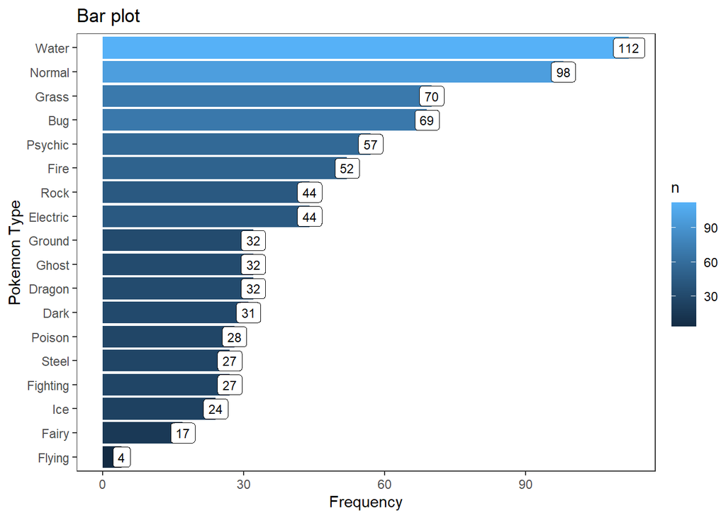

```r
Pokemon %>%
  group_by(type_1) %>%
  summarise(n = n()) %>%
  ggplot(aes(x = reorder(type_1, n), y = n)) +
  geom_bar(stat = "identity", aes(fill = n)) +
  coord_flip() +
  geom_label(aes(label = n), size = 3) +
  theme_test() +
  labs(x = "Pokemon Type", y = "Frequency", title = "Bar plot")
```

filter

```r
Pokemon_n<-Pokemon %>%
  filter(type_1 %in% c("Bug", "Fire", "Grass", "Normal", "Water", "Psychic"))

Pokemon_n$type_1<- as.factor(Pokemon_n$type_1)
Pokemon_n$legendary<- as.factor(Pokemon_n$legendary)
Pokemon_n$generation<- as.factor(Pokemon_n$generation)
```

split and v-fold (v=5)

```r
set.seed(3435)
Pokemon_split <- initial_split(Pokemon_n, strata = "type_1",prop=0.75)

Pokemon_train <- training(Pokemon_split)
Pokemon_test <- testing(Pokemon_split)

Pokemon_fold <- vfold_cv(Pokemon_train, v = 5,strata="type_1")
```

recipe

```r
recipe<-recipe(formula = type_1 ~ legendary + generation + sp_atk + attack + speed + defense + hp + sp_def, data = Pokemon_train) %>%
  step_dummy(c(legendary,generation)) %>%
  step_center(all_predictors()) %>%
  step_scale(all_predictors())
```

#Exercise 2

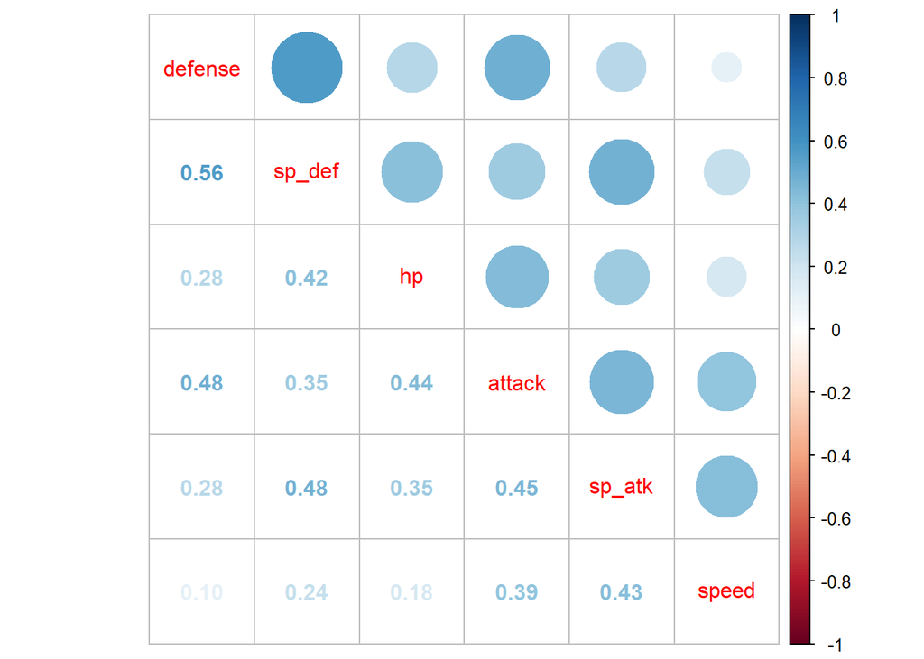

```r
library(corrplot)
C = cor(Pokemon_train[6:11])
corrplot.mixed(C, order = 'AOE')
```

The correlation coefficients are all positive, which means the relationships between each variables here are all positive. There are some stronger correlation between two of the variables, such as defense & sp_def, depense & attack, sp_def & hp, sp_def & attack, hp & attack, attack & sp_atk, sp_atk vs speed, where the strongest group here is defense & sp_def, the correlation coefficient between them is larger than 0.5.

#Exercise 3

workflow

```r
tree_spec <- decision_tree() %>%
  set_engine("rpart")

class_tree_spec <- tree_spec %>%
  set_mode("classification")

class_tree_wf <- workflow() %>%
  add_model(class_tree_spec %>% set_args(cost_complexity = tune())) %>%
  add_formula(type_1 ~ legendary + generation + hp + attack + defense + sp_atk + sp_def + speed)
```

tune & autoplot

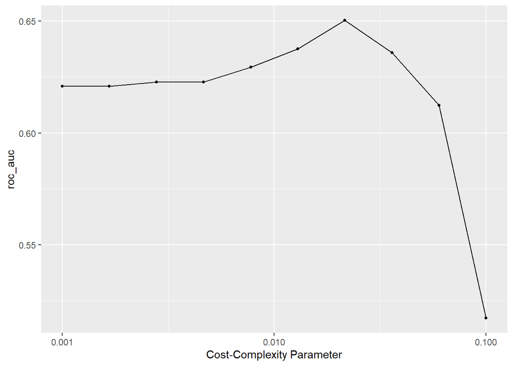

```r
param_grid <- grid_regular(cost_complexity(range = c(-3, -1)), levels = 10)

tune <- tune_grid(class_tree_wf,
                  resamples = Pokemon_fold,
                  grid = param_grid,
                  metrics = metric_set(roc_auc))
autoplot(tune)
```

#Exercise 4

```r
tune %>% collect_metrics()
```

```
## # A tibble: 10 × 7
##    cost_complexity .metric .estimator  mean     n std_err .config
##              <dbl> <chr>   <chr>      <dbl> <int>   <dbl> <chr>
##  1         0.001   roc_auc hand_till  0.621     5 0.0148  Preprocessor1_Model01
##  2         0.00167 roc_auc hand_till  0.621     5 0.0148  Preprocessor1_Model02
##  3         0.00278 roc_auc hand_till  0.623     5 0.0157  Preprocessor1_Model03
##  4         0.00464 roc_auc hand_till  0.623     5 0.0157  Preprocessor1_Model04
##  5         0.00774 roc_auc hand_till  0.629     5 0.0169  Preprocessor1_Model05
##  6         0.0129  roc_auc hand_till  0.638     5 0.0205  Preprocessor1_Model06
##  7         0.0215  roc_auc hand_till  0.650     5 0.0132  Preprocessor1_Model07
##  8         0.0359  roc_auc hand_till  0.636     5 0.0192  Preprocessor1_Model08
##  9         0.0599  roc_auc hand_till  0.612     5 0.00894 Preprocessor1_Model09
## 10         0.1     roc_auc hand_till  0.517     5 0.0172  Preprocessor1_Model10
```

```r
tune %>%
  collect_metrics()%>%
  arrange(desc(mean))%>%
  slice(1)
```

```
## # A tibble: 1 × 7
##   cost_complexity .metric .estimator  mean     n std_err .config
##             <dbl> <chr>   <chr>      <dbl> <int>   <dbl> <chr>
## 1          0.0215 roc_auc hand_till  0.650     5  0.0132 Preprocessor1_Model07
```

#Exercise 5 (1/2) rpart plot

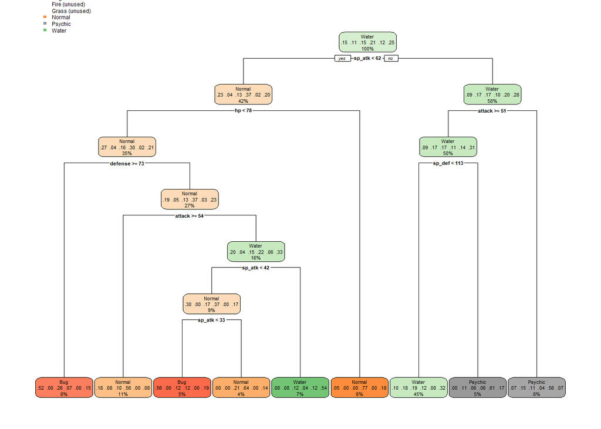

```r
best_complexity <- select_best(tune, matric = 'roc_auc')
class_tree_final <- finalize_workflow(class_tree_wf, best_complexity)
class_tree_final_fit <- fit(class_tree_final, data = Pokemon_train)

class_tree_final_fit %>%
  extract_fit_engine() %>%
  rpart.plot()
```

#Exercise 5 (2/2)

```r
forest_spec <- rand_forest() %>%
  set_engine("ranger", importance = 'impurity')%>%
  set_mode('classification')%>%
  set_args(mtry=tune(),trees=tune(),min_n=tune())

forest_wf<-workflow()%>%
  add_model(forest_spec)%>%
  add_recipe(recipe)
```

mtry: the number of predictor that randomly sampled at each split when creating tree model. trees: the number of trees included in our dataset. min_n: Minimum number of data points in a node required for further splitting of the node.

```r
grid<- grid_regular(mtry(range= c(1,8)),
                          trees(range = c(200,1000)),
                           min_n(range = c(5,20)),
                          levels = 8)
```

#Exercise 6

```r
library(ranger)
tune_forest<-tune_grid(
  forest_wf,
  resamples=Pokemon_fold,
  gird=grid,
  metric=metric_set(roc_auc))
```

```
## i Creating pre-processing data to finalize unknown parameter: mtry
```

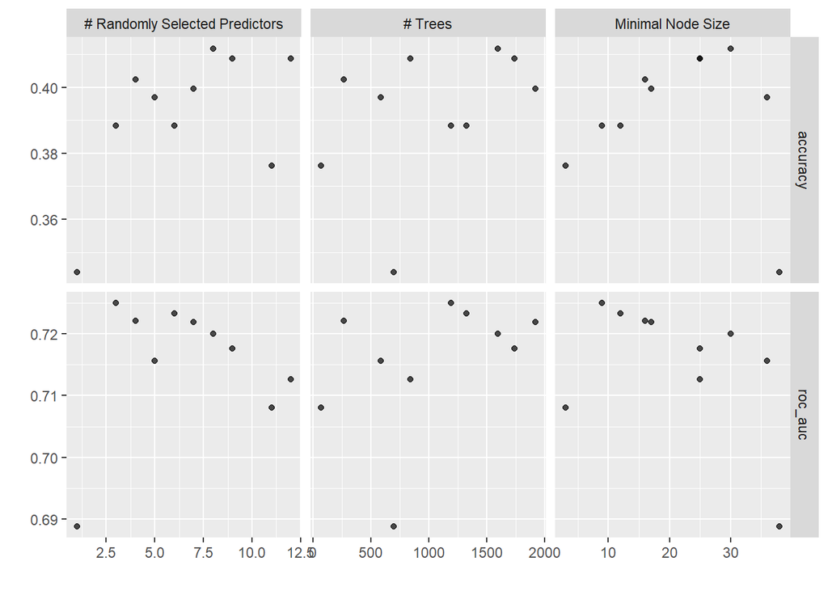

```r
autoplot(tune_forest)
```

#Exercise 7

```r
collect_metrics(tune_forest)%>%
  arrange(-mean)
```

```
## # A tibble: 20 × 9
##     mtry trees min_n .metric  .estimator  mean     n std_err .config
##    <int> <int> <int> <chr>    <chr>      <dbl> <int>   <dbl> <chr>
##  1     3  1190     9 roc_auc  hand_till  0.725     5  0.0186 Preprocessor1_Mode…
##  2     6  1325    12 roc_auc  hand_till  0.723     5  0.0169 Preprocessor1_Mode…
##  3     4   267    16 roc_auc  hand_till  0.722     5  0.0174 Preprocessor1_Mode…
##  4     7  1917    17 roc_auc  hand_till  0.722     5  0.0158 Preprocessor1_Mode…
##  5     8  1595    30 roc_auc  hand_till  0.720     5  0.0150 Preprocessor1_Mode…
##  6     9  1739    25 roc_auc  hand_till  0.718     5  0.0151 Preprocessor1_Mode…
##  7     5   587    36 roc_auc  hand_till  0.716     5  0.0147 Preprocessor1_Mode…
##  8    12   839    25 roc_auc  hand_till  0.713     5  0.0148 Preprocessor1_Mode…
##  9    11    71     3 roc_auc  hand_till  0.708     5  0.0110 Preprocessor1_Mode…
## 10     1   694    38 roc_auc  hand_till  0.689     5  0.0116 Preprocessor1_Mode…
## 11     8  1595    30 accuracy multiclass 0.412     5  0.0252 Preprocessor1_Mode…
## 12     9  1739    25 accuracy multiclass 0.409     5  0.0261 Preprocessor1_Mode…
## 13    12   839    25 accuracy multiclass 0.409     5  0.0220 Preprocessor1_Mode…
## 14     4   267    16 accuracy multiclass 0.402     5  0.0238 Preprocessor1_Mode…
## 15     7  1917    17 accuracy multiclass 0.400     5  0.0202 Preprocessor1_Mode…
## 16     5   587    36 accuracy multiclass 0.397     5  0.0251 Preprocessor1_Mode…
## 17     6  1325    12 accuracy multiclass 0.388     5  0.0275 Preprocessor1_Mode…
## 18     3  1190     9 accuracy multiclass 0.388     5  0.0242 Preprocessor1_Mode…
## 19    11    71     3 accuracy multiclass 0.376     5  0.0201 Preprocessor1_Mode…
## 20     1   694    38 accuracy multiclass 0.344     5  0.0271 Preprocessor1_Mode…
```

#Exercise 8

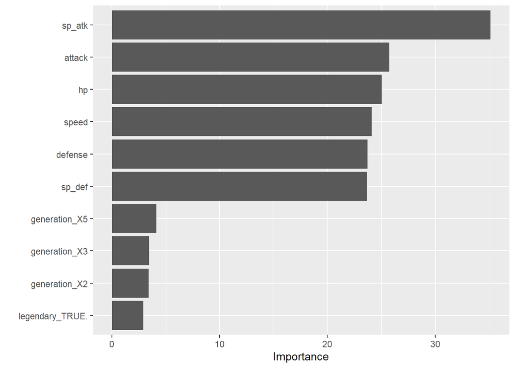

```r
best_forest<-select_best(tune_forest,metric = "roc_auc")
forest_final<-finalize_workflow(forest_wf,best_forest)
final_fit<-fit(forest_final,Pokemon_train)

final_fit %>%
  extract_fit_engine() %>%
  vip()
```

“sp_atk” were most useful, and “Legendary” were least useful. These results are what I expect.

#Exercise 9

```r
library(xgboost)
```

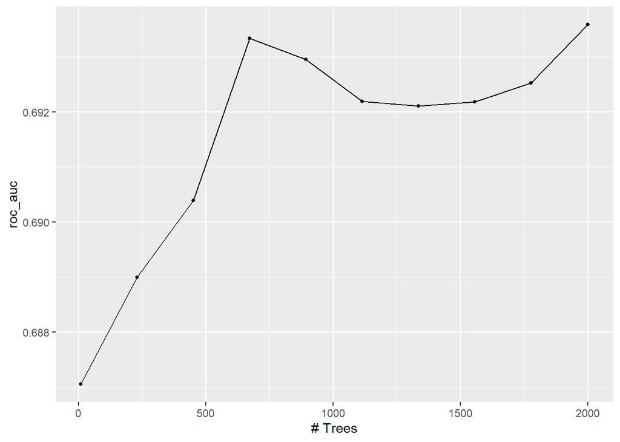

```r
boost_spec <- boost_tree(trees = tune(), tree_depth = 4) %>%
  set_engine("xgboost") %>%
  set_mode("classification")

boost_wf <- workflow()%>%
  add_model(boost_spec)%>%
  add_recipe(recipe)

grid2<- grid_regular(trees(range = c(10,2000) ),levels = 10)

boost_tune_res <- tune_grid(
  boost_wf,
  resamples = Pokemon_fold,
  grid = grid2,
  metrics = metric_set(roc_auc)
)

autoplot(boost_tune_res)
```

When the number of trees is less than about 750, the value of roc_auc increases. The value of roc_auc decreases when the number of trees is between about 750 and about 1250. When the number of trees is greater than about 1250 roc_auc increases again.

```r
collect_metrics(boost_tune_res) %>%
  arrange(-mean)
```

```
## # A tibble: 10 × 7
##    trees .metric .estimator  mean     n std_err .config
##    <int> <chr>   <chr>      <dbl> <int>   <dbl> <chr>
##  1  2000 roc_auc hand_till  0.694     5  0.0183 Preprocessor1_Model10
##  2   673 roc_auc hand_till  0.693     5  0.0194 Preprocessor1_Model04
##  3   894 roc_auc hand_till  0.693     5  0.0188 Preprocessor1_Model05
##  4  1778 roc_auc hand_till  0.693     5  0.0183 Preprocessor1_Model09
##  5  1115 roc_auc hand_till  0.692     5  0.0190 Preprocessor1_Model06
##  6  1557 roc_auc hand_till  0.692     5  0.0179 Preprocessor1_Model08
##  7  1336 roc_auc hand_till  0.692     5  0.0180 Preprocessor1_Model07
##  8   452 roc_auc hand_till  0.690     5  0.0192 Preprocessor1_Model03
##  9   231 roc_auc hand_till  0.689     5  0.0184 Preprocessor1_Model02
## 10    10 roc_auc hand_till  0.687     5  0.0121 Preprocessor1_Model01
```

The roc_auc of my best-performing boosted tree model on the folds is 0.6935841.

#Exercise 10

```r
pruned_roc_auc <- collect_metrics(tune) %>% arrange(-mean)
forest_roc_auc <- collect_metrics(tune_forest) %>% arrange(-mean)
boost_roc_auc <- collect_metrics(boost_tune_res) %>% arrange(-mean)
roc_auc_means <- c(pruned_roc_auc$mean[1], forest_roc_auc$mean[1], boost_roc_auc$mean[1])
Models <- c("Pruned Tree", "Random Forest", "Boosted Tree")
tibble(roc_auc = roc_auc_means, models = Models)
```

```
## # A tibble: 3 × 2
##   roc_auc models
##     <dbl> <chr>
## 1   0.650 Pruned Tree
## 2   0.725 Random Forest
## 3   0.694 Boosted Tree
```

The random forest model performed the best on folds.

```r
best_boost_final <- select_best(boost_tune_res)
best_boost_final_model <- finalize_workflow(boost_wf, best_boost_final)
best_boost_final_model_fit <- fit(best_boost_final_model, data = Pokemon_train)
```

```r
best_forest <- select_best(tune_forest)
best_forest_model <- finalize_workflow(forest_wf, best_forest)
best_forest_fit <- fit(best_forest_model, data = Pokemon_test)

prediction <- augment(best_boost_final_model_fit , new_data = Pokemon_test) %>%
  select(type_1, .pred_class, .pred_Bug,.pred_Fire, .pred_Grass, .pred_Normal, .pred_Psychic, .pred_Water)
accuracy(prediction, type_1, .pred_class)
```

```
## # A tibble: 1 × 3
##   .metric  .estimator .estimate
##   <chr>    <chr>          <dbl>
## 1 accuracy multiclass     0.393
```

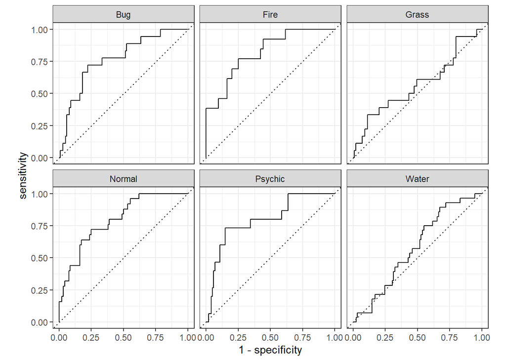

```r
prediction %>%
  roc_curve(type_1,.pred_Bug, .pred_Fire, .pred_Grass, .pred_Normal,.pred_Psychic, .pred_Water) %>% autoplot()
```

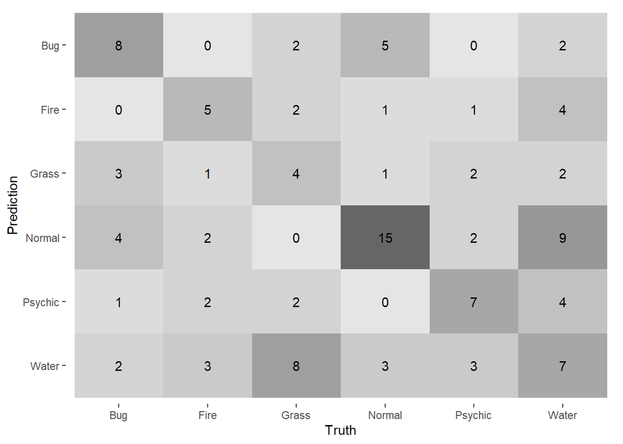

```r
prediction %>%
  conf_mat(type_1, .pred_class) %>%
  autoplot(type = "heatmap")
```

```r
Water<-8/(2+3+8+3+3+7)
Psychic<-7/(1+2+2+7+4)
Fire<-15/(4+2+15+2+9)
Grass<-4/(3+1+4+1+2+2)
Normal<-5/(5+2+1+1+4)
Bug<-8/(8+2+5+2)
rbind(Water,Psychic,Fire,Grass,Normal,Bug)
```

```
##              [,1]
## Water   0.3076923
## Psychic 0.4375000
## Fire    0.4687500
## Grass   0.3076923
## Normal  0.3846154
## Bug     0.4705882
```